# Risk Factor Analysis

## Outcome Variable

**Outcome Variable:** pers_wast

## Predictor Variables

**Intervention Variable:** feducyrs

**Adjustment Set:**

unadjusted

## Stratifying Variables

The analysis was stratified on these variable(s):

- agecat
- studyid
- country

## Data Summary

| agecat | studyid | country | feducyrs | pers_wast | n_cell | n |
| --- | --- | --- | --- | --- | --- | --- |
| 0-24 months | ki0047075b-MAL-ED | BANGLADESH | High | 0 | 48 | 138 |
| 0-24 months | ki0047075b-MAL-ED | BANGLADESH | High | 1 | 3 | 138 |
| 0-24 months | ki0047075b-MAL-ED | BANGLADESH | Low | 0 | 38 | 138 |
| 0-24 months | ki0047075b-MAL-ED | BANGLADESH | Low | 1 | 0 | 138 |
| 0-24 months | ki0047075b-MAL-ED | BANGLADESH | Medium | 0 | 45 | 138 |
| 0-24 months | ki0047075b-MAL-ED | BANGLADESH | Medium | 1 | 4 | 138 |
| 0-24 months | ki0047075b-MAL-ED | INDIA | High | 0 | 43 | 139 |
| 0-24 months | ki0047075b-MAL-ED | INDIA | High | 1 | 0 | 139 |
| 0-24 months | ki0047075b-MAL-ED | INDIA | Low | 0 | 51 | 139 |
| 0-24 months | ki0047075b-MAL-ED | INDIA | Low | 1 | 4 | 139 |
| 0-24 months | ki0047075b-MAL-ED | INDIA | Medium | 0 | 32 | 139 |
| 0-24 months | ki0047075b-MAL-ED | INDIA | Medium | 1 | 9 | 139 |
| 0-24 months | ki0047075b-MAL-ED | NEPAL | High | 0 | 40 | 96 |
| 0-24 months | ki0047075b-MAL-ED | NEPAL | High | 1 | 1 | 96 |
| 0-24 months | ki0047075b-MAL-ED | NEPAL | Low | 0 | 27 | 96 |
| 0-24 months | ki0047075b-MAL-ED | NEPAL | Low | 1 | 0 | 96 |
| 0-24 months | ki0047075b-MAL-ED | NEPAL | Medium | 0 | 27 | 96 |
| 0-24 months | ki0047075b-MAL-ED | NEPAL | Medium | 1 | 1 | 96 |
| 0-24 months | ki0047075b-MAL-ED | PERU | High | 0 | 110 | 234 |
| 0-24 months | ki0047075b-MAL-ED | PERU | High | 1 | 1 | 234 |
| 0-24 months | ki0047075b-MAL-ED | PERU | Low | 0 | 63 | 234 |
| 0-24 months | ki0047075b-MAL-ED | PERU | Low | 1 | 0 | 234 |
| 0-24 months | ki0047075b-MAL-ED | PERU | Medium | 0 | 60 | 234 |
| 0-24 months | ki0047075b-MAL-ED | PERU | Medium | 1 | 0 | 234 |
| 0-24 months | ki0047075b-MAL-ED | SOUTH AFRICA | High | 0 | 38 | 99 |
| 0-24 months | ki0047075b-MAL-ED | SOUTH AFRICA | High | 1 | 0 | 99 |
| 0-24 months | ki0047075b-MAL-ED | SOUTH AFRICA | Low | 0 | 35 | 99 |
| 0-24 months | ki0047075b-MAL-ED | SOUTH AFRICA | Low | 1 | 1 | 99 |
| 0-24 months | ki0047075b-MAL-ED | SOUTH AFRICA | Medium | 0 | 25 | 99 |
| 0-24 months | ki0047075b-MAL-ED | SOUTH AFRICA | Medium | 1 | 0 | 99 |

[output cut: 294 more lines]

The following strata were considered:

- agecat: 0-24 months, studyid: ki0047075b-MAL-ED, country: BANGLADESH
- agecat: 0-24 months, studyid: ki0047075b-MAL-ED, country: INDIA
- agecat: 0-24 months, studyid: ki0047075b-MAL-ED, country: NEPAL
- agecat: 0-24 months, studyid: ki0047075b-MAL-ED, country: PERU
- agecat: 0-24 months, studyid: ki0047075b-MAL-ED, country: SOUTH AFRICA
- agecat: 0-24 months, studyid: ki0047075b-MAL-ED, country: TANZANIA, UNITED REPUBLIC OF
- agecat: 0-24 months, studyid: ki1000304b-SAS-CompFeed, country: INDIA
- agecat: 0-24 months, studyid: ki1000304b-SAS-FoodSuppl, country: INDIA
- agecat: 0-24 months, studyid: ki1017093b-PROVIDE, country: BANGLADESH
- agecat: 0-24 months, studyid: ki1017093c-NIH-Crypto, country: BANGLADESH
- agecat: 0-24 months, studyid: ki1066203-TanzaniaChild2, country: TANZANIA, UNITED REPUBLIC OF
- agecat: 0-24 months, studyid: ki1113344-GMS-Nepal, country: NEPAL
- agecat: 0-24 months, studyid: ki1119695-PROBIT, country: BELARUS
- agecat: 0-24 months, studyid: ki1126311-ZVITAMBO, country: ZIMBABWE
- agecat: 0-24 months, studyid: ki1135781-COHORTS, country: GUATEMALA
- agecat: 0-24 months, studyid: ki1135781-COHORTS, country: INDIA
- agecat: 0-24 months, studyid: ki1135781-COHORTS, country: PHILIPPINES
- agecat: 0-24 months, studyid: ki1148112-LCNI-5, country: MALAWI
- agecat: 0-24 months, studyid: kiGH5241-JiVitA-3, country: BANGLADESH
- agecat: 0-24 months, studyid: kiGH5241-JiVitA-4, country: BANGLADESH
- agecat: 0-6 months, studyid: ki0047075b-MAL-ED, country: BANGLADESH
- agecat: 0-6 months, studyid: ki0047075b-MAL-ED, country: INDIA
- agecat: 0-6 months, studyid: ki0047075b-MAL-ED, country: NEPAL
- agecat: 0-6 months, studyid: ki0047075b-MAL-ED, country: PERU
- agecat: 0-6 months, studyid: ki0047075b-MAL-ED, country: SOUTH AFRICA
- agecat: 0-6 months, studyid: ki0047075b-MAL-ED, country: TANZANIA, UNITED REPUBLIC OF
- agecat: 0-6 months, studyid: ki1017093b-PROVIDE, country: BANGLADESH
- agecat: 0-6 months, studyid: ki1017093c-NIH-Crypto, country: BANGLADESH
- agecat: 0-6 months, studyid: ki1066203-TanzaniaChild2, country: TANZANIA, UNITED REPUBLIC OF
- agecat: 0-6 months, studyid: ki1113344-GMS-Nepal, country: NEPAL
- agecat: 0-6 months, studyid: ki1119695-PROBIT, country: BELARUS
- agecat: 0-6 months, studyid: ki1126311-ZVITAMBO, country: ZIMBABWE
- agecat: 0-6 months, studyid: ki1135781-COHORTS, country: PHILIPPINES
- agecat: 0-6 months, studyid: kiGH5241-JiVitA-3, country: BANGLADESH
- agecat: 6-24 months, studyid: ki0047075b-MAL-ED, country: BANGLADESH
- agecat: 6-24 months, studyid: ki0047075b-MAL-ED, country: INDIA
- agecat: 6-24 months, studyid: ki0047075b-MAL-ED, country: NEPAL
- agecat: 6-24 months, studyid: ki0047075b-MAL-ED, country: PERU
- agecat: 6-24 months, studyid: ki0047075b-MAL-ED, country: SOUTH AFRICA
- agecat: 6-24 months, studyid: ki0047075b-MAL-ED, country: TANZANIA, UNITED REPUBLIC OF
- agecat: 6-24 months, studyid: ki1000304b-SAS-CompFeed, country: INDIA
- agecat: 6-24 months, studyid: ki1000304b-SAS-FoodSuppl, country: INDIA
- agecat: 6-24 months, studyid: ki1017093b-PROVIDE, country: BANGLADESH
- agecat: 6-24 months, studyid: ki1017093c-NIH-Crypto, country: BANGLADESH
- agecat: 6-24 months, studyid: ki1066203-TanzaniaChild2, country: TANZANIA, UNITED REPUBLIC OF
- agecat: 6-24 months, studyid: ki1113344-GMS-Nepal, country: NEPAL
- agecat: 6-24 months, studyid: ki1119695-PROBIT, country: BELARUS
- agecat: 6-24 months, studyid: ki1126311-ZVITAMBO, country: ZIMBABWE
- agecat: 6-24 months, studyid: ki1135781-COHORTS, country: GUATEMALA
- agecat: 6-24 months, studyid: ki1135781-COHORTS, country: INDIA
- agecat: 6-24 months, studyid: ki1135781-COHORTS, country: PHILIPPINES
- agecat: 6-24 months, studyid: ki1148112-LCNI-5, country: MALAWI
- agecat: 6-24 months, studyid: kiGH5241-JiVitA-3, country: BANGLADESH
- agecat: 6-24 months, studyid: kiGH5241-JiVitA-4, country: BANGLADESH

### Dropped Strata

Some strata were dropped due to rare outcomes:

- agecat: 0-24 months, studyid: ki0047075b-MAL-ED, country: BANGLADESH
- agecat: 0-24 months, studyid: ki0047075b-MAL-ED, country: INDIA
- agecat: 0-24 months, studyid: ki0047075b-MAL-ED, country: NEPAL
- agecat: 0-24 months, studyid: ki0047075b-MAL-ED, country: PERU
- agecat: 0-24 months, studyid: ki0047075b-MAL-ED, country: SOUTH AFRICA
- agecat: 0-24 months, studyid: ki0047075b-MAL-ED, country: TANZANIA, UNITED REPUBLIC OF
- agecat: 0-24 months, studyid: ki1000304b-SAS-FoodSuppl, country: INDIA
- agecat: 0-24 months, studyid: ki1017093b-PROVIDE, country: BANGLADESH
- agecat: 0-24 months, studyid: ki1017093c-NIH-Crypto, country: BANGLADESH
- agecat: 0-24 months, studyid: ki1148112-LCNI-5, country: MALAWI
- agecat: 0-6 months, studyid: ki0047075b-MAL-ED, country: BANGLADESH
- agecat: 0-6 months, studyid: ki0047075b-MAL-ED, country: INDIA
- agecat: 0-6 months, studyid: ki0047075b-MAL-ED, country: NEPAL
- agecat: 0-6 months, studyid: ki0047075b-MAL-ED, country: PERU
- agecat: 0-6 months, studyid: ki0047075b-MAL-ED, country: SOUTH AFRICA
- agecat: 0-6 months, studyid: ki0047075b-MAL-ED, country: TANZANIA, UNITED REPUBLIC OF
- agecat: 0-6 months, studyid: ki1017093b-PROVIDE, country: BANGLADESH
- agecat: 0-6 months, studyid: ki1017093c-NIH-Crypto, country: BANGLADESH
- agecat: 0-6 months, studyid: ki1126311-ZVITAMBO, country: ZIMBABWE
- agecat: 0-6 months, studyid: kiGH5241-JiVitA-3, country: BANGLADESH
- agecat: 6-24 months, studyid: ki0047075b-MAL-ED, country: BANGLADESH
- agecat: 6-24 months, studyid: ki0047075b-MAL-ED, country: INDIA
- agecat: 6-24 months, studyid: ki0047075b-MAL-ED, country: NEPAL
- agecat: 6-24 months, studyid: ki0047075b-MAL-ED, country: PERU
- agecat: 6-24 months, studyid: ki0047075b-MAL-ED, country: SOUTH AFRICA
- agecat: 6-24 months, studyid: ki0047075b-MAL-ED, country: TANZANIA, UNITED REPUBLIC OF
- agecat: 6-24 months, studyid: ki1000304b-SAS-FoodSuppl, country: INDIA
- agecat: 6-24 months, studyid: ki1017093b-PROVIDE, country: BANGLADESH
- agecat: 6-24 months, studyid: ki1017093c-NIH-Crypto, country: BANGLADESH
- agecat: 6-24 months, studyid: ki1148112-LCNI-5, country: MALAWI

## Methods Detail

We’re interested in the causal parameters $E[Y_a]$ for all values of $a \in \mathcal{A}$. These parameters represent the mean outcome if, possibly contrary to fact, we intervened to set all units to have $A=a$. Under the randomization and positivity assumptions, these are identified by the statistical parameters $\psi_a=E_W[E_{Y|A,W}(Y|A=a,W)]$. In addition, we’re interested in the mean of $Y$, $E[Y]$ under no intervention (the observed mean). We will estimate these parameters by using SuperLearner to fit the relevant likelihood factors – $E_{Y|A,W}(Y|A=a,W)$ and $p(A=a|W)$, and then updating our likelihood fit using a joint TMLE.

For unadjusted analyses ($W=\{\}$), initial likelihoods were estimated using Lrnr_glm to estimate the simple $E(Y|A)$ and Lrnr_mean to estimate $p(A)$. For adjusted analyses, a small library containing Lrnr_glmnet, Lrnr_xgboost, and Lrnr_mean was used.

Having estimated these parameters, we will then use the delta method to estimate relative risks and attributable risks relative to a prespecified baseline level of $A$.

# Results Detail

## Results Plots

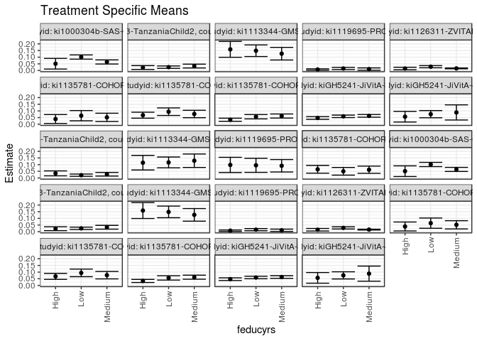

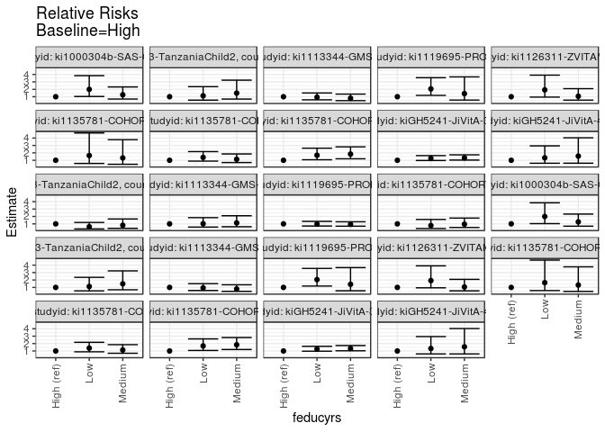

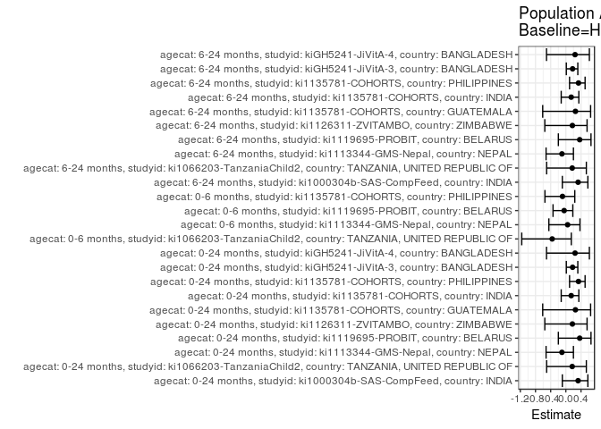

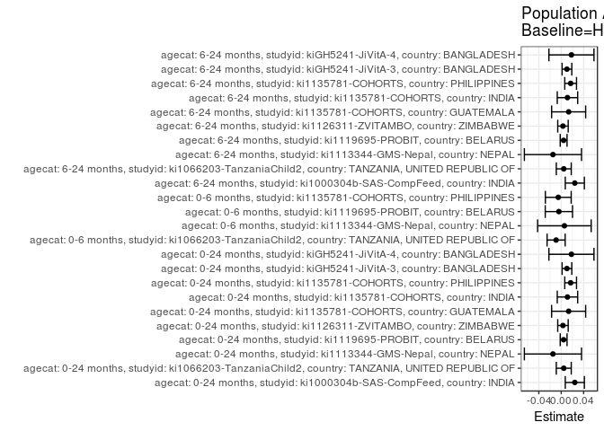

## Results Table

### Parameter: TSM

| agecat | studyid | country | intervention_level | baseline_level | estimate | ci_lower | ci_upper |
| --- | --- | --- | --- | --- | --- | --- | --- |
| 0-24 months | ki1000304b-SAS-CompFeed | INDIA | High | NA | 0.0508475 | 0.0109061 | 0.0907888 |
| 0-24 months | ki1000304b-SAS-CompFeed | INDIA | Low | NA | 0.1011905 | 0.0854021 | 0.1169788 |
| 0-24 months | ki1000304b-SAS-CompFeed | INDIA | Medium | NA | 0.0642857 | 0.0488298 | 0.0797417 |
| 0-24 months | ki1066203-TanzaniaChild2 | TANZANIA, UNITED REPUBLIC OF | High | NA | 0.0223881 | 0.0079228 | 0.0368534 |
| 0-24 months | ki1066203-TanzaniaChild2 | TANZANIA, UNITED REPUBLIC OF | Low | NA | 0.0251736 | 0.0161255 | 0.0342217 |
| 0-24 months | ki1066203-TanzaniaChild2 | TANZANIA, UNITED REPUBLIC OF | Medium | NA | 0.0332779 | 0.0189349 | 0.0476209 |
| 0-24 months | ki1113344-GMS-Nepal | NEPAL | High | NA | 0.1586207 | 0.0991083 | 0.2181331 |
| 0-24 months | ki1113344-GMS-Nepal | NEPAL | Low | NA | 0.1484375 | 0.1048486 | 0.1920264 |
| 0-24 months | ki1113344-GMS-Nepal | NEPAL | Medium | NA | 0.1263158 | 0.0790393 | 0.1735923 |
| 0-24 months | ki1119695-PROBIT | BELARUS | High | NA | 0.0074442 | 0.0020141 | 0.0128743 |
| 0-24 months | ki1119695-PROBIT | BELARUS | Low | NA | 0.0152871 | 0.0071141 | 0.0234601 |
| 0-24 months | ki1119695-PROBIT | BELARUS | Medium | NA | 0.0105708 | 0.0017344 | 0.0194072 |
| 0-24 months | ki1126311-ZVITAMBO | ZIMBABWE | High | NA | 0.0148026 | 0.0052031 | 0.0244022 |
| 0-24 months | ki1126311-ZVITAMBO | ZIMBABWE | Low | NA | 0.0284450 | 0.0202527 | 0.0366373 |
| 0-24 months | ki1126311-ZVITAMBO | ZIMBABWE | Medium | NA | 0.0157297 | 0.0127864 | 0.0186730 |
| 0-24 months | ki1135781-COHORTS | GUATEMALA | High | NA | 0.0390625 | 0.0054636 | 0.0726614 |
| 0-24 months | ki1135781-COHORTS | GUATEMALA | Low | NA | 0.0641026 | 0.0256263 | 0.1025788 |
| 0-24 months | ki1135781-COHORTS | GUATEMALA | Medium | NA | 0.0515464 | 0.0203999 | 0.0826929 |
| 0-24 months | ki1135781-COHORTS | INDIA | High | NA | 0.0677618 | 0.0454305 | 0.0900931 |
| 0-24 months | ki1135781-COHORTS | INDIA | Low | NA | 0.0940594 | 0.0655831 | 0.1225357 |
| 0-24 months | ki1135781-COHORTS | INDIA | Medium | NA | 0.0769231 | 0.0490351 | 0.1048110 |
| 0-24 months | ki1135781-COHORTS | PHILIPPINES | High | NA | 0.0335861 | 0.0219612 | 0.0452111 |
| 0-24 months | ki1135781-COHORTS | PHILIPPINES | Low | NA | 0.0564103 | 0.0402163 | 0.0726042 |
| 0-24 months | ki1135781-COHORTS | PHILIPPINES | Medium | NA | 0.0617155 | 0.0464586 | 0.0769723 |
| 0-24 months | kiGH5241-JiVitA-3 | BANGLADESH | High | NA | 0.0471363 | 0.0369400 | 0.0573327 |
| 0-24 months | kiGH5241-JiVitA-3 | BANGLADESH | Low | NA | 0.0592899 | 0.0500016 | 0.0685782 |
| 0-24 months | kiGH5241-JiVitA-3 | BANGLADESH | Medium | NA | 0.0629344 | 0.0528260 | 0.0730427 |
| 0-24 months | kiGH5241-JiVitA-4 | BANGLADESH | High | NA | 0.0566038 | 0.0166371 | 0.0965705 |
| 0-24 months | kiGH5241-JiVitA-4 | BANGLADESH | Low | NA | 0.0755064 | 0.0485627 | 0.1024502 |
| 0-24 months | kiGH5241-JiVitA-4 | BANGLADESH | Medium | NA | 0.0884956 | 0.0317277 | 0.1452635 |
| 0-6 months | ki1066203-TanzaniaChild2 | TANZANIA, UNITED REPUBLIC OF | High | NA | 0.0344828 | 0.0160596 | 0.0529059 |
| 0-6 months | ki1066203-TanzaniaChild2 | TANZANIA, UNITED REPUBLIC OF | Low | NA | 0.0209281 | 0.0124631 | 0.0293931 |
| 0-6 months | ki1066203-TanzaniaChild2 | TANZANIA, UNITED REPUBLIC OF | Medium | NA | 0.0278261 | 0.0143793 | 0.0412729 |
| 0-6 months | ki1113344-GMS-Nepal | NEPAL | High | NA | 0.1145038 | 0.0599258 | 0.1690818 |
| 0-6 months | ki1113344-GMS-Nepal | NEPAL | Low | NA | 0.1166667 | 0.0760149 | 0.1573185 |
| 0-6 months | ki1113344-GMS-Nepal | NEPAL | Medium | NA | 0.1294118 | 0.0789086 | 0.1799149 |
| 0-6 months | ki1119695-PROBIT | BELARUS | High | NA | 0.0978148 | 0.0407328 | 0.1548968 |
| 0-6 months | ki1119695-PROBIT | BELARUS | Low | NA | 0.0948775 | 0.0419991 | 0.1477560 |
| 0-6 months | ki1119695-PROBIT | BELARUS | Medium | NA | 0.0914767 | 0.0447504 | 0.1382030 |
| 0-6 months | ki1135781-COHORTS | PHILIPPINES | High | NA | 0.0649819 | 0.0359361 | 0.0940278 |
| 0-6 months | ki1135781-COHORTS | PHILIPPINES | Low | NA | 0.0500000 | 0.0211827 | 0.0788173 |
| 0-6 months | ki1135781-COHORTS | PHILIPPINES | Medium | NA | 0.0618893 | 0.0349191 | 0.0888594 |
| 6-24 months | ki1000304b-SAS-CompFeed | INDIA | High | NA | 0.0508475 | 0.0109061 | 0.0907888 |
| 6-24 months | ki1000304b-SAS-CompFeed | INDIA | Low | NA | 0.1011905 | 0.0854021 | 0.1169788 |
| 6-24 months | ki1000304b-SAS-CompFeed | INDIA | Medium | NA | 0.0642857 | 0.0488298 | 0.0797417 |
| 6-24 months | ki1066203-TanzaniaChild2 | TANZANIA, UNITED REPUBLIC OF | High | NA | 0.0223881 | 0.0079228 | 0.0368534 |
| 6-24 months | ki1066203-TanzaniaChild2 | TANZANIA, UNITED REPUBLIC OF | Low | NA | 0.0251736 | 0.0161255 | 0.0342217 |
| 6-24 months | ki1066203-TanzaniaChild2 | TANZANIA, UNITED REPUBLIC OF | Medium | NA | 0.0332779 | 0.0189349 | 0.0476209 |
| 6-24 months | ki1113344-GMS-Nepal | NEPAL | High | NA | 0.1586207 | 0.0991083 | 0.2181331 |
| 6-24 months | ki1113344-GMS-Nepal | NEPAL | Low | NA | 0.1484375 | 0.1048486 | 0.1920264 |
| 6-24 months | ki1113344-GMS-Nepal | NEPAL | Medium | NA | 0.1263158 | 0.0790393 | 0.1735923 |
| 6-24 months | ki1119695-PROBIT | BELARUS | High | NA | 0.0074442 | 0.0020141 | 0.0128743 |
| 6-24 months | ki1119695-PROBIT | BELARUS | Low | NA | 0.0152871 | 0.0071141 | 0.0234601 |
| 6-24 months | ki1119695-PROBIT | BELARUS | Medium | NA | 0.0105708 | 0.0017344 | 0.0194072 |
| 6-24 months | ki1126311-ZVITAMBO | ZIMBABWE | High | NA | 0.0148026 | 0.0052031 | 0.0244022 |
| 6-24 months | ki1126311-ZVITAMBO | ZIMBABWE | Low | NA | 0.0284450 | 0.0202527 | 0.0366373 |
| 6-24 months | ki1126311-ZVITAMBO | ZIMBABWE | Medium | NA | 0.0157297 | 0.0127864 | 0.0186730 |
| 6-24 months | ki1135781-COHORTS | GUATEMALA | High | NA | 0.0390625 | 0.0054636 | 0.0726614 |
| 6-24 months | ki1135781-COHORTS | GUATEMALA | Low | NA | 0.0641026 | 0.0256263 | 0.1025788 |
| 6-24 months | ki1135781-COHORTS | GUATEMALA | Medium | NA | 0.0515464 | 0.0203999 | 0.0826929 |
| 6-24 months | ki1135781-COHORTS | INDIA | High | NA | 0.0677618 | 0.0454305 | 0.0900931 |
| 6-24 months | ki1135781-COHORTS | INDIA | Low | NA | 0.0940594 | 0.0655831 | 0.1225357 |
| 6-24 months | ki1135781-COHORTS | INDIA | Medium | NA | 0.0769231 | 0.0490351 | 0.1048110 |
| 6-24 months | ki1135781-COHORTS | PHILIPPINES | High | NA | 0.0335861 | 0.0219612 | 0.0452111 |
| 6-24 months | ki1135781-COHORTS | PHILIPPINES | Low | NA | 0.0564103 | 0.0402163 | 0.0726042 |
| 6-24 months | ki1135781-COHORTS | PHILIPPINES | Medium | NA | 0.0617155 | 0.0464586 | 0.0769723 |
| 6-24 months | kiGH5241-JiVitA-3 | BANGLADESH | High | NA | 0.0471363 | 0.0369400 | 0.0573327 |
| 6-24 months | kiGH5241-JiVitA-3 | BANGLADESH | Low | NA | 0.0592899 | 0.0500016 | 0.0685782 |
| 6-24 months | kiGH5241-JiVitA-3 | BANGLADESH | Medium | NA | 0.0629344 | 0.0528260 | 0.0730427 |
| 6-24 months | kiGH5241-JiVitA-4 | BANGLADESH | High | NA | 0.0566038 | 0.0166371 | 0.0965705 |
| 6-24 months | kiGH5241-JiVitA-4 | BANGLADESH | Low | NA | 0.0755064 | 0.0485627 | 0.1024502 |
| 6-24 months | kiGH5241-JiVitA-4 | BANGLADESH | Medium | NA | 0.0884956 | 0.0317277 | 0.1452635 |

### Parameter: E(Y)

| agecat | studyid | country | intervention_level | baseline_level | estimate | ci_lower | ci_upper |
| --- | --- | --- | --- | --- | --- | --- | --- |
| 0-24 months | ki1000304b-SAS-CompFeed | INDIA | NA | NA | 0.0751174 | 0.0517075 | 0.0985272 |
| 0-24 months | ki1066203-TanzaniaChild2 | TANZANIA, UNITED REPUBLIC OF | NA | NA | 0.0269142 | 0.0200799 | 0.0337484 |
| 0-24 months | ki1113344-GMS-Nepal | NEPAL | NA | NA | 0.1438240 | 0.1155088 | 0.1721392 |
| 0-24 months | ki1119695-PROBIT | BELARUS | NA | NA | 0.0117264 | 0.0044979 | 0.0189548 |
| 0-24 months | ki1126311-ZVITAMBO | ZIMBABWE | NA | NA | 0.0178887 | 0.0151586 | 0.0206188 |
| 0-24 months | ki1135781-COHORTS | GUATEMALA | NA | NA | 0.0523013 | 0.0323220 | 0.0722805 |
| 0-24 months | ki1135781-COHORTS | INDIA | NA | NA | 0.0789050 | 0.0639058 | 0.0939041 |
| 0-24 months | ki1135781-COHORTS | PHILIPPINES | NA | NA | 0.0503949 | 0.0420785 | 0.0587113 |
| 0-24 months | kiGH5241-JiVitA-3 | BANGLADESH | NA | NA | 0.0573419 | 0.0514451 | 0.0632387 |
| 0-24 months | kiGH5241-JiVitA-4 | BANGLADESH | NA | NA | 0.0748031 | 0.0530263 | 0.0965800 |
| 0-6 months | ki1066203-TanzaniaChild2 | TANZANIA, UNITED REPUBLIC OF | NA | NA | 0.0253535 | 0.0185487 | 0.0321583 |
| 0-6 months | ki1113344-GMS-Nepal | NEPAL | NA | NA | 0.1201479 | 0.0927249 | 0.1475708 |
| 0-6 months | ki1119695-PROBIT | BELARUS | NA | NA | 0.0936183 | 0.0451320 | 0.1421047 |
| 0-6 months | ki1135781-COHORTS | PHILIPPINES | NA | NA | 0.0597015 | 0.0433139 | 0.0760891 |
| 6-24 months | ki1000304b-SAS-CompFeed | INDIA | NA | NA | 0.0751174 | 0.0517075 | 0.0985272 |
| 6-24 months | ki1066203-TanzaniaChild2 | TANZANIA, UNITED REPUBLIC OF | NA | NA | 0.0269142 | 0.0200799 | 0.0337484 |
| 6-24 months | ki1113344-GMS-Nepal | NEPAL | NA | NA | 0.1438240 | 0.1155088 | 0.1721392 |
| 6-24 months | ki1119695-PROBIT | BELARUS | NA | NA | 0.0117264 | 0.0044979 | 0.0189548 |
| 6-24 months | ki1126311-ZVITAMBO | ZIMBABWE | NA | NA | 0.0178887 | 0.0151586 | 0.0206188 |
| 6-24 months | ki1135781-COHORTS | GUATEMALA | NA | NA | 0.0523013 | 0.0323220 | 0.0722805 |
| 6-24 months | ki1135781-COHORTS | INDIA | NA | NA | 0.0789050 | 0.0639058 | 0.0939041 |
| 6-24 months | ki1135781-COHORTS | PHILIPPINES | NA | NA | 0.0503949 | 0.0420785 | 0.0587113 |
| 6-24 months | kiGH5241-JiVitA-3 | BANGLADESH | NA | NA | 0.0573419 | 0.0514451 | 0.0632387 |
| 6-24 months | kiGH5241-JiVitA-4 | BANGLADESH | NA | NA | 0.0748031 | 0.0530263 | 0.0965800 |

### Parameter: RR

| agecat | studyid | country | intervention_level | baseline_level | estimate | ci_lower | ci_upper |
| --- | --- | --- | --- | --- | --- | --- | --- |
| 0-24 months | ki1000304b-SAS-CompFeed | INDIA | High | High | 1.0000000 | 1.0000000 | 1.000000 |
| 0-24 months | ki1000304b-SAS-CompFeed | INDIA | Low | High | 1.9900794 | 1.0314072 | 3.839818 |
| 0-24 months | ki1000304b-SAS-CompFeed | INDIA | Medium | High | 1.2642857 | 0.6895423 | 2.318086 |
| 0-24 months | ki1066203-TanzaniaChild2 | TANZANIA, UNITED REPUBLIC OF | High | High | 1.0000000 | 1.0000000 | 1.000000 |
| 0-24 months | ki1066203-TanzaniaChild2 | TANZANIA, UNITED REPUBLIC OF | Low | High | 1.1244213 | 0.5368195 | 2.355211 |
| 0-24 months | ki1066203-TanzaniaChild2 | TANZANIA, UNITED REPUBLIC OF | Medium | High | 1.4864115 | 0.6836450 | 3.231822 |
| 0-24 months | ki1113344-GMS-Nepal | NEPAL | High | High | 1.0000000 | 1.0000000 | 1.000000 |
| 0-24 months | ki1113344-GMS-Nepal | NEPAL | Low | High | 0.9358016 | 0.5811227 | 1.506953 |
| 0-24 months | ki1113344-GMS-Nepal | NEPAL | Medium | High | 0.7963387 | 0.4687533 | 1.352855 |
| 0-24 months | ki1119695-PROBIT | BELARUS | High | High | 1.0000000 | 1.0000000 | 1.000000 |
| 0-24 months | ki1119695-PROBIT | BELARUS | Low | High | 2.0535670 | 1.1826494 | 3.565839 |
| 0-24 months | ki1119695-PROBIT | BELARUS | Medium | High | 1.4200141 | 0.5489462 | 3.673292 |
| 0-24 months | ki1126311-ZVITAMBO | ZIMBABWE | High | High | 1.0000000 | 1.0000000 | 1.000000 |
| 0-24 months | ki1126311-ZVITAMBO | ZIMBABWE | Low | High | 1.9216182 | 0.9451494 | 3.906913 |
| 0-24 months | ki1126311-ZVITAMBO | ZIMBABWE | Medium | High | 1.0626274 | 0.5410654 | 2.086951 |
| 0-24 months | ki1135781-COHORTS | GUATEMALA | High | High | 1.0000000 | 1.0000000 | 1.000000 |
| 0-24 months | ki1135781-COHORTS | GUATEMALA | Low | High | 1.6410256 | 0.5749130 | 4.684126 |
| 0-24 months | ki1135781-COHORTS | GUATEMALA | Medium | High | 1.3195876 | 0.4612384 | 3.775296 |
| 0-24 months | ki1135781-COHORTS | INDIA | High | High | 1.0000000 | 1.0000000 | 1.000000 |
| 0-24 months | ki1135781-COHORTS | INDIA | Low | High | 1.3880888 | 0.8872928 | 2.171539 |
| 0-24 months | ki1135781-COHORTS | INDIA | Medium | High | 1.1351981 | 0.6954913 | 1.852898 |
| 0-24 months | ki1135781-COHORTS | PHILIPPINES | High | High | 1.0000000 | 1.0000000 | 1.000000 |
| 0-24 months | ki1135781-COHORTS | PHILIPPINES | Low | High | 1.6795699 | 1.0712826 | 2.633250 |
| 0-24 months | ki1135781-COHORTS | PHILIPPINES | Medium | High | 1.8375287 | 1.2009106 | 2.811626 |
| 0-24 months | kiGH5241-JiVitA-3 | BANGLADESH | High | High | 1.0000000 | 1.0000000 | 1.000000 |
| 0-24 months | kiGH5241-JiVitA-3 | BANGLADESH | Low | High | 1.2578384 | 0.9707351 | 1.629855 |
| 0-24 months | kiGH5241-JiVitA-3 | BANGLADESH | Medium | High | 1.3351559 | 1.0284724 | 1.733290 |
| 0-24 months | kiGH5241-JiVitA-4 | BANGLADESH | High | High | 1.0000000 | 1.0000000 | 1.000000 |
| 0-24 months | kiGH5241-JiVitA-4 | BANGLADESH | Low | High | 1.3339472 | 0.6040752 | 2.945685 |
| 0-24 months | kiGH5241-JiVitA-4 | BANGLADESH | Medium | High | 1.5634218 | 0.6063153 | 4.031381 |
| 0-6 months | ki1066203-TanzaniaChild2 | TANZANIA, UNITED REPUBLIC OF | High | High | 1.0000000 | 1.0000000 | 1.000000 |
| 0-6 months | ki1066203-TanzaniaChild2 | TANZANIA, UNITED REPUBLIC OF | Low | High | 0.6069154 | 0.3105289 | 1.186190 |
| 0-6 months | ki1066203-TanzaniaChild2 | TANZANIA, UNITED REPUBLIC OF | Medium | High | 0.8069565 | 0.3926323 | 1.658495 |
| 0-6 months | ki1113344-GMS-Nepal | NEPAL | High | High | 1.0000000 | 1.0000000 | 1.000000 |
| 0-6 months | ki1113344-GMS-Nepal | NEPAL | Low | High | 1.0188889 | 0.5645557 | 1.838852 |
| 0-6 months | ki1113344-GMS-Nepal | NEPAL | Medium | High | 1.1301961 | 0.6104029 | 2.092623 |
| 0-6 months | ki1119695-PROBIT | BELARUS | High | High | 1.0000000 | 1.0000000 | 1.000000 |
| 0-6 months | ki1119695-PROBIT | BELARUS | Low | High | 0.9699711 | 0.7071601 | 1.330454 |
| 0-6 months | ki1119695-PROBIT | BELARUS | Medium | High | 0.9352037 | 0.6850202 | 1.276759 |
| 0-6 months | ki1135781-COHORTS | PHILIPPINES | High | High | 1.0000000 | 1.0000000 | 1.000000 |
| 0-6 months | ki1135781-COHORTS | PHILIPPINES | Low | High | 0.7694444 | 0.3710385 | 1.595642 |
| 0-6 months | ki1135781-COHORTS | PHILIPPINES | Medium | High | 0.9524068 | 0.5101642 | 1.778013 |
| 6-24 months | ki1000304b-SAS-CompFeed | INDIA | High | High | 1.0000000 | 1.0000000 | 1.000000 |
| 6-24 months | ki1000304b-SAS-CompFeed | INDIA | Low | High | 1.9900794 | 1.0314072 | 3.839818 |
| 6-24 months | ki1000304b-SAS-CompFeed | INDIA | Medium | High | 1.2642857 | 0.6895423 | 2.318086 |
| 6-24 months | ki1066203-TanzaniaChild2 | TANZANIA, UNITED REPUBLIC OF | High | High | 1.0000000 | 1.0000000 | 1.000000 |
| 6-24 months | ki1066203-TanzaniaChild2 | TANZANIA, UNITED REPUBLIC OF | Low | High | 1.1244213 | 0.5368195 | 2.355211 |
| 6-24 months | ki1066203-TanzaniaChild2 | TANZANIA, UNITED REPUBLIC OF | Medium | High | 1.4864115 | 0.6836450 | 3.231822 |
| 6-24 months | ki1113344-GMS-Nepal | NEPAL | High | High | 1.0000000 | 1.0000000 | 1.000000 |
| 6-24 months | ki1113344-GMS-Nepal | NEPAL | Low | High | 0.9358016 | 0.5811227 | 1.506953 |
| 6-24 months | ki1113344-GMS-Nepal | NEPAL | Medium | High | 0.7963387 | 0.4687533 | 1.352855 |
| 6-24 months | ki1119695-PROBIT | BELARUS | High | High | 1.0000000 | 1.0000000 | 1.000000 |
| 6-24 months | ki1119695-PROBIT | BELARUS | Low | High | 2.0535670 | 1.1826494 | 3.565839 |
| 6-24 months | ki1119695-PROBIT | BELARUS | Medium | High | 1.4200141 | 0.5489462 | 3.673292 |
| 6-24 months | ki1126311-ZVITAMBO | ZIMBABWE | High | High | 1.0000000 | 1.0000000 | 1.000000 |
| 6-24 months | ki1126311-ZVITAMBO | ZIMBABWE | Low | High | 1.9216182 | 0.9451494 | 3.906913 |
| 6-24 months | ki1126311-ZVITAMBO | ZIMBABWE | Medium | High | 1.0626274 | 0.5410654 | 2.086951 |
| 6-24 months | ki1135781-COHORTS | GUATEMALA | High | High | 1.0000000 | 1.0000000 | 1.000000 |
| 6-24 months | ki1135781-COHORTS | GUATEMALA | Low | High | 1.6410256 | 0.5749130 | 4.684126 |
| 6-24 months | ki1135781-COHORTS | GUATEMALA | Medium | High | 1.3195876 | 0.4612384 | 3.775296 |
| 6-24 months | ki1135781-COHORTS | INDIA | High | High | 1.0000000 | 1.0000000 | 1.000000 |
| 6-24 months | ki1135781-COHORTS | INDIA | Low | High | 1.3880888 | 0.8872928 | 2.171539 |
| 6-24 months | ki1135781-COHORTS | INDIA | Medium | High | 1.1351981 | 0.6954913 | 1.852898 |
| 6-24 months | ki1135781-COHORTS | PHILIPPINES | High | High | 1.0000000 | 1.0000000 | 1.000000 |
| 6-24 months | ki1135781-COHORTS | PHILIPPINES | Low | High | 1.6795699 | 1.0712826 | 2.633250 |
| 6-24 months | ki1135781-COHORTS | PHILIPPINES | Medium | High | 1.8375287 | 1.2009106 | 2.811626 |
| 6-24 months | kiGH5241-JiVitA-3 | BANGLADESH | High | High | 1.0000000 | 1.0000000 | 1.000000 |
| 6-24 months | kiGH5241-JiVitA-3 | BANGLADESH | Low | High | 1.2578384 | 0.9707351 | 1.629855 |
| 6-24 months | kiGH5241-JiVitA-3 | BANGLADESH | Medium | High | 1.3351559 | 1.0284724 | 1.733290 |
| 6-24 months | kiGH5241-JiVitA-4 | BANGLADESH | High | High | 1.0000000 | 1.0000000 | 1.000000 |
| 6-24 months | kiGH5241-JiVitA-4 | BANGLADESH | Low | High | 1.3339472 | 0.6040752 | 2.945685 |
| 6-24 months | kiGH5241-JiVitA-4 | BANGLADESH | Medium | High | 1.5634218 | 0.6063153 | 4.031381 |

### Parameter: PAR

| agecat | studyid | country | intervention_level | baseline_level | estimate | ci_lower | ci_upper |
| --- | --- | --- | --- | --- | --- | --- | --- |
| 0-24 months | ki1000304b-SAS-CompFeed | INDIA | High | NA | 0.0242699 | 0.0072146 | 0.0413252 |
| 0-24 months | ki1066203-TanzaniaChild2 | TANZANIA, UNITED REPUBLIC OF | High | NA | 0.0045261 | -0.0088113 | 0.0178635 |
| 0-24 months | ki1113344-GMS-Nepal | NEPAL | High | NA | -0.0147967 | -0.0658415 | 0.0362482 |
| 0-24 months | ki1119695-PROBIT | BELARUS | High | NA | 0.0042822 | -0.0018227 | 0.0103871 |
| 0-24 months | ki1126311-ZVITAMBO | ZIMBABWE | High | NA | 0.0030861 | -0.0062537 | 0.0124258 |
| 0-24 months | ki1135781-COHORTS | GUATEMALA | High | NA | 0.0132388 | -0.0171499 | 0.0436274 |
| 0-24 months | ki1135781-COHORTS | INDIA | High | NA | 0.0111432 | -0.0070936 | 0.0293800 |
| 0-24 months | ki1135781-COHORTS | PHILIPPINES | High | NA | 0.0168088 | 0.0062977 | 0.0273198 |
| 0-24 months | kiGH5241-JiVitA-3 | BANGLADESH | High | NA | 0.0102056 | 0.0015620 | 0.0188491 |
| 0-24 months | kiGH5241-JiVitA-4 | BANGLADESH | High | NA | 0.0181994 | -0.0220417 | 0.0584404 |
| 0-6 months | ki1066203-TanzaniaChild2 | TANZANIA, UNITED REPUBLIC OF | High | NA | -0.0091293 | -0.0252829 | 0.0070244 |
| 0-6 months | ki1113344-GMS-Nepal | NEPAL | High | NA | 0.0056441 | -0.0421911 | 0.0534792 |
| 0-6 months | ki1119695-PROBIT | BELARUS | High | NA | -0.0041964 | -0.0285458 | 0.0201529 |
| 0-6 months | ki1135781-COHORTS | PHILIPPINES | High | NA | -0.0052805 | -0.0283215 | 0.0177605 |
| 6-24 months | ki1000304b-SAS-CompFeed | INDIA | High | NA | 0.0242699 | 0.0072146 | 0.0413252 |
| 6-24 months | ki1066203-TanzaniaChild2 | TANZANIA, UNITED REPUBLIC OF | High | NA | 0.0045261 | -0.0088113 | 0.0178635 |
| 6-24 months | ki1113344-GMS-Nepal | NEPAL | High | NA | -0.0147967 | -0.0658415 | 0.0362482 |
| 6-24 months | ki1119695-PROBIT | BELARUS | High | NA | 0.0042822 | -0.0018227 | 0.0103871 |
| 6-24 months | ki1126311-ZVITAMBO | ZIMBABWE | High | NA | 0.0030861 | -0.0062537 | 0.0124258 |
| 6-24 months | ki1135781-COHORTS | GUATEMALA | High | NA | 0.0132388 | -0.0171499 | 0.0436274 |
| 6-24 months | ki1135781-COHORTS | INDIA | High | NA | 0.0111432 | -0.0070936 | 0.0293800 |
| 6-24 months | ki1135781-COHORTS | PHILIPPINES | High | NA | 0.0168088 | 0.0062977 | 0.0273198 |
| 6-24 months | kiGH5241-JiVitA-3 | BANGLADESH | High | NA | 0.0102056 | 0.0015620 | 0.0188491 |
| 6-24 months | kiGH5241-JiVitA-4 | BANGLADESH | High | NA | 0.0181994 | -0.0220417 | 0.0584404 |

### Parameter: PAF

| agecat | studyid | country | intervention_level | baseline_level | estimate | ci_lower | ci_upper |
| --- | --- | --- | --- | --- | --- | --- | --- |
| 0-24 months | ki1000304b-SAS-CompFeed | INDIA | High | NA | 0.3230932 | -0.0925159 | 0.5805985 |
| 0-24 months | ki1066203-TanzaniaChild2 | TANZANIA, UNITED REPUBLIC OF | High | NA | 0.1681678 | -0.5060612 | 0.5405599 |
| 0-24 months | ki1113344-GMS-Nepal | NEPAL | High | NA | -0.1028803 | -0.5210479 | 0.2003243 |
| 0-24 months | ki1119695-PROBIT | BELARUS | High | NA | 0.3651778 | -0.1974058 | 0.6634398 |
| 0-24 months | ki1126311-ZVITAMBO | ZIMBABWE | High | NA | 0.1725146 | -0.5539660 | 0.5593648 |
| 0-24 months | ki1135781-COHORTS | GUATEMALA | High | NA | 0.2531250 | -0.6098525 | 0.6534948 |
| 0-24 months | ki1135781-COHORTS | INDIA | High | NA | 0.1412228 | -0.1222469 | 0.3428378 |
| 0-24 months | ki1135781-COHORTS | PHILIPPINES | High | NA | 0.3335409 | 0.0979768 | 0.5075872 |
| 0-24 months | kiGH5241-JiVitA-3 | BANGLADESH | High | NA | 0.1779775 | 0.0123899 | 0.3158018 |
| 0-24 months | kiGH5241-JiVitA-4 | BANGLADESH | High | NA | 0.2432969 | -0.5090809 | 0.6205641 |
| 0-6 months | ki1066203-TanzaniaChild2 | TANZANIA, UNITED REPUBLIC OF | High | NA | -0.3600796 | -1.1618510 | 0.1443368 |
| 0-6 months | ki1113344-GMS-Nepal | NEPAL | High | NA | 0.0469759 | -0.4470583 | 0.3723440 |
| 0-6 months | ki1119695-PROBIT | BELARUS | High | NA | -0.0448248 | -0.3375056 | 0.1838098 |
| 0-6 months | ki1135781-COHORTS | PHILIPPINES | High | NA | -0.0884477 | -0.5507252 | 0.2360230 |
| 6-24 months | ki1000304b-SAS-CompFeed | INDIA | High | NA | 0.3230932 | -0.0925159 | 0.5805985 |
| 6-24 months | ki1066203-TanzaniaChild2 | TANZANIA, UNITED REPUBLIC OF | High | NA | 0.1681678 | -0.5060612 | 0.5405599 |
| 6-24 months | ki1113344-GMS-Nepal | NEPAL | High | NA | -0.1028803 | -0.5210479 | 0.2003243 |
| 6-24 months | ki1119695-PROBIT | BELARUS | High | NA | 0.3651778 | -0.1974058 | 0.6634398 |
| 6-24 months | ki1126311-ZVITAMBO | ZIMBABWE | High | NA | 0.1725146 | -0.5539660 | 0.5593648 |
| 6-24 months | ki1135781-COHORTS | GUATEMALA | High | NA | 0.2531250 | -0.6098525 | 0.6534948 |
| 6-24 months | ki1135781-COHORTS | INDIA | High | NA | 0.1412228 | -0.1222469 | 0.3428378 |
| 6-24 months | ki1135781-COHORTS | PHILIPPINES | High | NA | 0.3335409 | 0.0979768 | 0.5075872 |
| 6-24 months | kiGH5241-JiVitA-3 | BANGLADESH | High | NA | 0.1779775 | 0.0123899 | 0.3158018 |
| 6-24 months | kiGH5241-JiVitA-4 | BANGLADESH | High | NA | 0.2432969 | -0.5090809 | 0.6205641 |